# Data Visualization - badge

LASER Institute Foundation Learning Lab 3

2022-07-14

[figure not shown]

The final activity for each learning lab provides space to work with data and to reflect on how the concepts and techniques introduced in each lab might apply to your own research.

To earn a badge for each lab, you are required to respond to a set of prompts for two parts:

- In Part I, you will reflect on your understanding of key concepts and begin to think about potential next steps for your own study.
- In Part II, you will create a simple data product in R that demonstrates your ability to apply a data analysis technique introduced in this learning lab.

### Part I: Reflect and Plan

Use the institutional library (e.g. [NCSU Library](https://www.lib.ncsu.edu/#articles)), [Google Scholar](https://scholar.google.com/) or search engine to locate a research article, presentation, or resource that applies learning analytics analysis to an educational context or topic of interest. More specifically, **locate a study that makes use of one of the data structures we learned today.** You are also welcome to select one of your research papers.

1. Provide an APA citation for your selected study.
   - Lai, R.P.Y. (2021). Teachers’ ontological perspectives of computational thinking and assessment: A text mining approach. *Journal of Educational Computing Research, 60*(3), 661-695
2. What educational issue, “problem of practice,” and/or questions were addressed?
   - Lai was examining how computer science teachers think about what computational thinking is and the extent to which it differs between teachers.
3. What are some common approaches EDA approaches used and what did they entail?
   - Lai used bar graphs to display the most frequently used words to describe CT, as well as the TF-IDF.
4. How were data visualization or feature engineering used to support analysis, if at all? What were the key findings or conclusions?
   - The author used graphs to represent the frequency of terms alongside the word clouds. The most frequent terms were “logic” and “think.”
5. Finally, what value, if any, might education practitioners find in these results?
   - I think the greatest value of bar graphs in relation to text mining is that it provides easily interpretable representations of frequency, whereas word clouds don’t resonate with some quant folks because they seem, idk, silly (?) or non-quantifiable.

Draft a new research question of guided by the the phases of the Learning Anlytics Workflow. Or use one of your current research questions.

1. What educational issue, “problem of practice,” and/or questions is addressed??
   - What are the most frequently used terms in the Texas districts’ responses to their needs regarding a move to 100% online testing?
2. Briefly describe any steps of the EDA approach that will be used..
   - I will use text mining with ggplot to represent the term frequency in the open-ended survey responses.
3. What elements of EDA might require human judgement and decision making?
   - The human judgement part comes into play when deciding how or if to layer the visualizations and also how or if to disaggregate findings by levels of a predictor.

### Part II: Data Product

In our Learning Analytics code-along, we only scratched the surface on the number of ways that we can wrangle the data.

Using one of the data sets provided in the data folder, your goal for this lab is to extend the Data Visualizations using `ggplot` for Learning Analytics. You have three options for completing the Data Product portion: You can create the visualization exercise provided. Create a visualization of your choice using a data set from the data folder Create a visualization using your own data.

I highly recommend creating a new R script in your lab-3 folder to complete this task. When your code is ready to share, use the code chunk below to share the final code for your model and answer the questions that follow.

Exercise 1: - Using the `sci-online to create a basic visualization that: + Examine the relationship between two categorical variables. + Add an appropriate title to your chart. + Add a caption that poses a question educators may have about this data that your visualization could help answer.

```r
# Kim's FINAL CODE HERE
#Thanks Jenn and Jeanne for collab'ing with me on this! :)
#load libraries
library(tidyverse)
library(here)
```

```r
library(ggplot2)

#read in data
sci_classes <- read_csv("data/sci-online-classes.csv")
sci_classes
```

```
## # A tibble: 603 × 30
##    student_id course_id     total_points_poss… total_points_ea… percentage_earn…
##         <dbl> <chr>                      <dbl>            <dbl>            <dbl>
##  1      43146 FrScA-S216-02               3280             2220            0.677
##  2      44638 OcnA-S116-01                3531             2672            0.757
##  3      47448 FrScA-S216-01               2870             1897            0.661
##  4      47979 OcnA-S216-01                4562             3090            0.677
##  5      48797 PhysA-S116-01               2207             1910            0.865
##  6      51943 FrScA-S216-03               4208             3596            0.855
##  7      52326 AnPhA-S216-01               4325             2255            0.521
##  8      52446 PhysA-S116-01               2086             1719            0.824
##  9      53447 FrScA-S116-01               4655             3149            0.676
## 10      53475 FrScA-S116-02               1710             1402            0.820
## # … with 593 more rows, and 25 more variables: subject <chr>, semester <chr>,
## #   section <chr>, Gradebook_Item <chr>, Grade_Category <lgl>,
## #   FinalGradeCEMS <dbl>, Points_Possible <dbl>, Points_Earned <dbl>,
## #   Gender <chr>, q1 <dbl>, q2 <dbl>, q3 <dbl>, q4 <dbl>, q5 <dbl>, q6 <dbl>,
## #   q7 <dbl>, q8 <dbl>, q9 <dbl>, q10 <dbl>, TimeSpent <dbl>,
## #   TimeSpent_hours <dbl>, TimeSpent_std <dbl>, int <dbl>, pc <dbl>, uv <dbl>
```

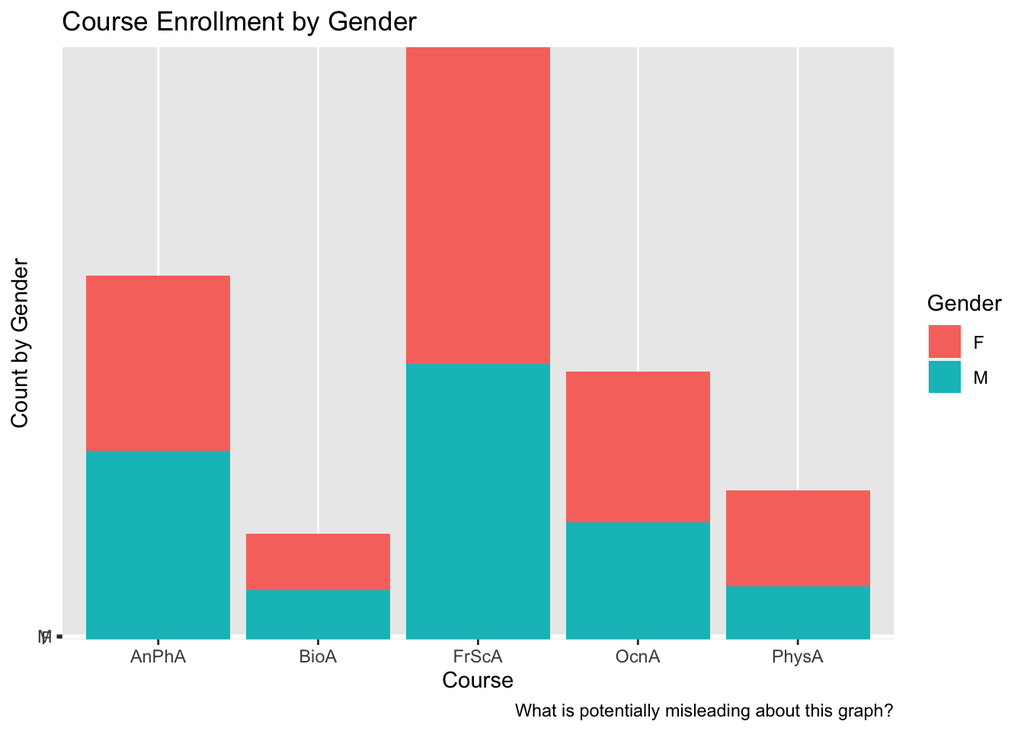

```r
#create histogram
sci_classes %>%
  ggplot(aes(fill=Gender, y=Gender, x=subject)) +
  geom_bar(position="stack", stat="identity") +
  labs(title="Course Enrollment by Gender", caption = "What is potentially misleading about this graph?", x="Course", y = "Count by Gender")
```

Exercise 2: - Using the `sci-online to create a basic visualization that: + examines the relationship between two continuous variables. (scatterplot with layers, #’ a log-log or line plot, or one using coord functions.) + Add an appropriate title to your chart. + Add a caption that poses a question educators may have about this data that your visualization could help answer. + Add or adjust any aesthetics to improve the readability of visual appeal of your viz. + Use a color scale if appropriate to modify the default colors used by ggplot. + Adjust or remove your legend as appropriate.

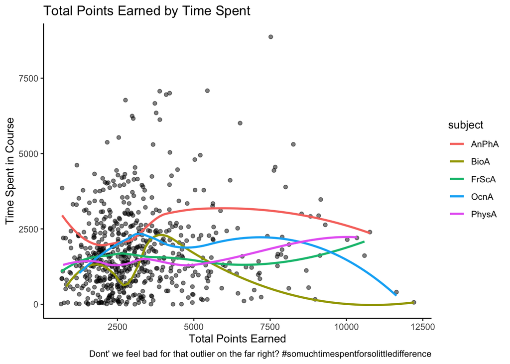

```r
# Kim's FINAL CODE HERE
ggplot(data = sci_classes, mapping = aes(x = total_points_earned, y = TimeSpent)) +
  geom_point(alpha=0.5) +
  geom_smooth(mapping = aes(color = subject), se = FALSE)+
  labs(title="Total Points Earned by Time Spent", caption = "Dont' we feel bad for that outlier on the far right? #somuchtimespentforsolittledifference", x="Total Points Earned", y = "Time Spent in Course") +
  theme_classic()
```

### Knit & Submit

Congratulations, you’ve completed your Foundation Badge on Learning Analytics Workflow! Complete the following steps to submit your work for review by:

1. Change the name of the author: in the [YAML header](https://monashdatafluency.github.io/r-rep-res/yaml-header.html) at the very top of this document to your name. As noted in [Reproducible Research in R](https://monashdatafluency.github.io/r-rep-res/index.html), The YAML header controls the style and feel for knitted document but doesn’t actually display in the final output.
2. Click the yarn icon above to “knit” your data product to a [HTML](https://bookdown.org/yihui/rmarkdown/html-document.html) file that will be saved in your R Project folder.
3. Commit your changes in GitHub Desktop and push them to your online GitHub repository.
4. Publish your HTML page the web using one of the following [publishing methods](https://rpubs.com/cathydatascience/518692): Publish on [RPubs](https://rpubs.com/) by clicking the “Publish” button located in the Viewer Pane when you knit your document. Note, you will need to quickly create a RPubs account. Publishing on GitHub using either [GitHub Pages](https://pages.github.com/) or the [HTML previewer](http://htmlpreview.github.io/).
5. Post a new discussion on GitHub to our [Foundations Badges forum](https://github.com/orgs/laser-institute/teams/foundations/discussions/2). In your post, include a link to your published web page and `write` a short reflection highlighting one thing you learned from this lab and one thing you’d like to explore further.